# iGraph1: From Zero to Hero

2022-10-08

## igraph

igraph is a R library for analyzing graphs/networks.

There are alternatives but igraph has most of the fundamental measures already implemented.

Read the documentation carefully and test measures/metrics yourself on toy models to be sure that you understood the process used for computing the measure.

## Installing igraph

```r
#install.packages("igraph")

library(igraph)
```

## Creating a toy graph

An undirected graph with 3 edges

```r
g1 <- graph(edges=c(1,2, 2,3, 3,1), n=3, directed=F)

g1
```

```
## IGRAPH dd55b5f U--- 3 3 --
## + edges from dd55b5f:
## [1] 1--2 2--3 1--3
```

## Creating another toy graph

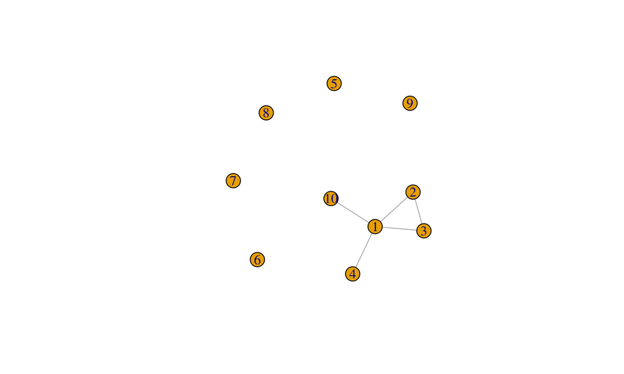

```r
# now with 10 vertices
g2 <- graph( edges=c(1,2, 2,3, 3,1, 4,1, 10,1), n=10 , directed = F)
plot(g2)
```

## Creating another toy graph

A directed graph with three edges

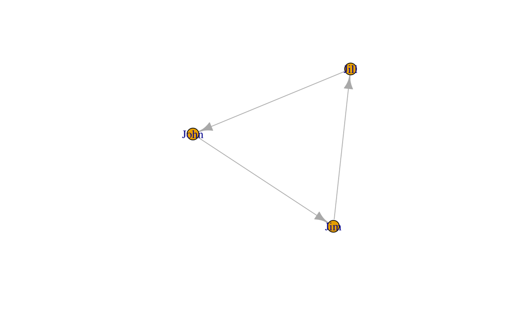

```r
g3 <- graph( c("John", "Jim", "Jim", "Jill", "Jill", "John")) # named vertices
# When the edge list has vertex names, the number of nodes is not needed
plot(g3)
```

## Creating another toy graph

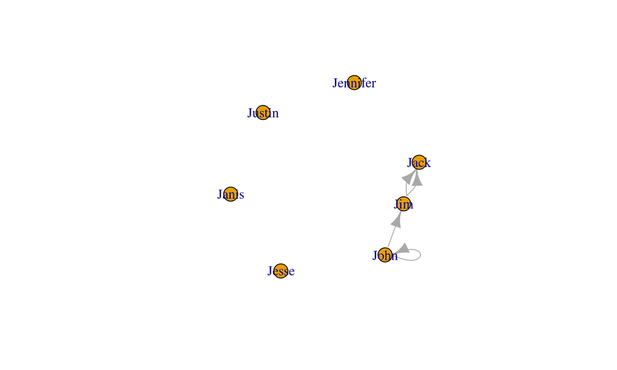

```r
g4 <- graph( c("John", "Jim", "Jim", "Jack", "Jim", "Jack", "John", "John"),
             isolates=c("Jesse", "Janis", "Jennifer", "Justin") )
# In named graphs we can specify isolates by providing a list of their names.
plot(g4)
```

## A better visualization

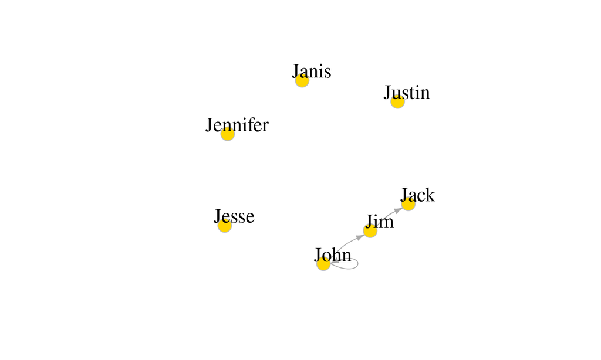

```r
plot(g4, edge.arrow.size=.5, vertex.color="gold", vertex.size=15,
     vertex.frame.color="gray", vertex.label.color="black",
     vertex.label.cex=1.5, vertex.label.dist=2, edge.curved=0.2)
```

## Edge, vertex, and network attributes

Here we will see how to:

- Access and manipulate vertex
- Access and manipulate edges

## Access vertices and edges

As vectors

```r
V(g4)
```

```
## + 7/7 vertices, named, from 1e83c6b:
## [1] John     Jim      Jack     Jesse    Janis    Jennifer Justin
```

```r
E(g4)
```

```
## + 4/4 edges from 1e83c6b (vertex names):
## [1] John->Jim  Jim ->Jack Jim ->Jack John->John
```

```r
V(g4)[2:6]
```

```
## + 5/7 vertices, named, from 1e83c6b:
## [1] Jim      Jack     Jesse    Janis    Jennifer
```

```r
E(g4)[2]
```

```
## + 1/4 edge from 1e83c6b (vertex names):
## [1] Jim->Jack
```

## Or directly accessing the network adjacency matrix

```r
g4[]
```

```
## 7 x 7 sparse Matrix of class "dgCMatrix"
##          John Jim Jack Jesse Janis Jennifer Justin
## John        1   1    .     .     .        .      .
## Jim         .   .    2     .     .        .      .
## Jack        .   .    .     .     .        .      .
## Jesse       .   .    .     .     .        .      .
## Janis       .   .    .     .     .        .      .
## Jennifer    .   .    .     .     .        .      .
## Justin      .   .    .     .     .        .      .
```

You may notice that this is the sparse version (we are saving space by not including the 0s)

## Or directly accessing the network adjacency matrix

```r
get.adjacency(g4, sparse = F)
```

```
##          John Jim Jack Jesse Janis Jennifer Justin
## John        1   1    0     0     0        0      0
## Jim         0   0    2     0     0        0      0
## Jack        0   0    0     0     0        0      0
## Jesse       0   0    0     0     0        0      0
## Janis       0   0    0     0     0        0      0
## Jennifer    0   0    0     0     0        0      0
## Justin      0   0    0     0     0        0      0
```

```r
g4[1,]
```

```
##     John      Jim     Jack    Jesse    Janis Jennifer   Justin
##        1        1        0        0        0        0        0
```

## Add attributes to the network, vertices, or edges

```r
V(g4)$name # automatically generated when we created the network
```

```
## [1] "John"     "Jim"      "Jack"     "Jesse"    "Janis"    "Jennifer" "Justin"
```

```r
V(g4)$gender <- c("male", "male", "male", "male", "female", "female", "male")
E(g4)$type <- "email" # Edge attribute, assign "email" to all edges
E(g4)$weight <- sample(10,ecount(g4))    # Edge weight, setting all existing edges to 10

g4
```

```
## IGRAPH 1e83c6b DNW- 7 4 --
## + attr: name (v/c), gender (v/c), type (e/c), weight (e/n)
## + edges from 1e83c6b (vertex names):
## [1] John->Jim  Jim ->Jack Jim ->Jack John->John
```

```r
E(g4)$weight
```

```
## [1]  9  7  5 10
```

## Looking at all attributes

```r
vertex_attr(g4)
```

```
## $name
## [1] "John"     "Jim"      "Jack"     "Jesse"    "Janis"    "Jennifer" "Justin"
##
## $gender
## [1] "male"   "male"   "male"   "male"   "female" "female" "male"
```

```r
edge_attr(g4)
```

```
## $type
## [1] "email" "email" "email" "email"
##
## $weight
## [1]  9  7  5 10
```

```r
graph_attr(g4)
```

```
## named list()
```

## Another way to set attributes

```r
g4 <- set_graph_attr(g4, "name", "Email Network")
g4 <- set_graph_attr(g4, "Collection Year", "2000")

graph_attr_names(g4)
```

```
## [1] "name"            "Collection Year"
```

```r
g4 <- delete_graph_attr(g4, "Collection Year")
graph_attr(g4)
```

```
## $name
## [1] "Email Network"
```

similarly we can use set_edge_attr() and set_vertex_attr()

## Simplify

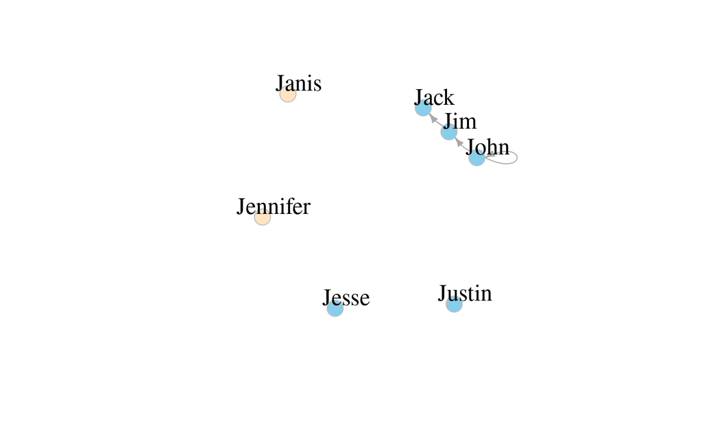

```r
g4 <- set_vertex_attr(g4,"color",value=c("skyblue", "skyblue", "skyblue", "skyblue",
                                         "bisque", "bisque", "skyblue"))

plot(g4, edge.arrow.size=.5, vertex.color=V(g4)$color, vertex.size=15,
     vertex.frame.color="gray", vertex.label.color="black",
     vertex.label.cex=1.5, vertex.label.dist=2, edge.curved=0.2)
```

## Simplify

```r
g4
```

```
## IGRAPH 1e83c6b DNW- 7 4 -- Email Network
## + attr: name (g/c), name (v/c), gender (v/c), color (v/c), type (e/c),
## | weight (e/n)
## + edges from 1e83c6b (vertex names):
## [1] John->Jim  Jim ->Jack Jim ->Jack John->John
```

- g4 has two edges going from Jim to Jack, and a loop from John to himself.
- We can simplify our graph to remove loops & multiple edges between the same nodes.

## Simplify

```r
g4_simplified <- simplify(g4, remove.multiple = T, remove.loops = F,
                          edge.attr.comb=list(weight="sum", type="ignore"))
#this way of simplifying doesn't keep EDGE multiplicity
g4_simplified
```

```
## IGRAPH a2e3662 DNW- 7 3 -- Email Network
## + attr: name (g/c), name (v/c), gender (v/c), color (v/c), weight (e/n)
## + edges from a2e3662 (vertex names):
## [1] John->John John->Jim  Jim ->Jack
```

```r
E(g4_simplified)$weight
```

```
## [1] 10  9 12
```

## Simplify

But if we assign a weight attribute (unitary) to each edge then simplifying counts their multiplicity

```r
E(g4)$weight = 1

g4_simplified <- simplify(g4, remove.multiple = T, remove.loops = F,
                          edge.attr.comb=list(weight="sum", type="ignore"))
#this keeps edge attributes because we assigned them in advance
g4_simplified
```

```
## IGRAPH 60418fd DNW- 7 3 -- Email Network
## + attr: name (g/c), name (v/c), gender (v/c), color (v/c), weight (e/n)
## + edges from 60418fd (vertex names):
## [1] John->John John->Jim  Jim ->Jack
```

```r
E(g4_simplified)$weight
```

```
## [1] 1 1 2
```

## Simplify

Finally we obtain

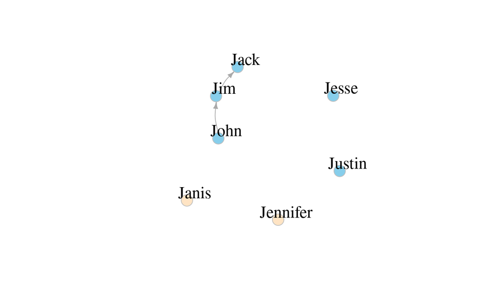

```r
g4_simplified <- simplify(g4, remove.multiple = T, remove.loops = T, edge.attr.comb=list(weight="sum", type="ignore"))

plot(g4_simplified, edge.arrow.size=.5, vertex.color=V(g4)$color, vertex.size=15,
     vertex.frame.color="gray", vertex.label.color="black",
     vertex.label.cex=1.5, vertex.label.dist=2, edge.curved=0.2)
```

## Specific Graphs

Graphs with a “notable” structure

- Empty Graph

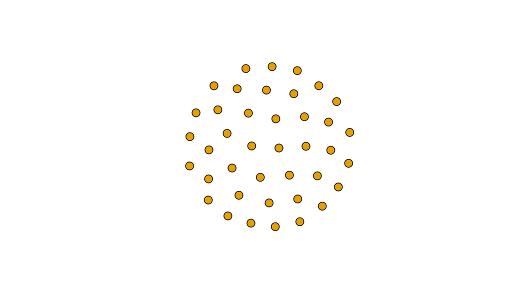

```r
eg <- make_empty_graph(40)

plot(eg, vertex.size=10, vertex.label=NA)
```

## Specific Graphs

Graphs with a “notable” structure

- Full Graph aka Clique

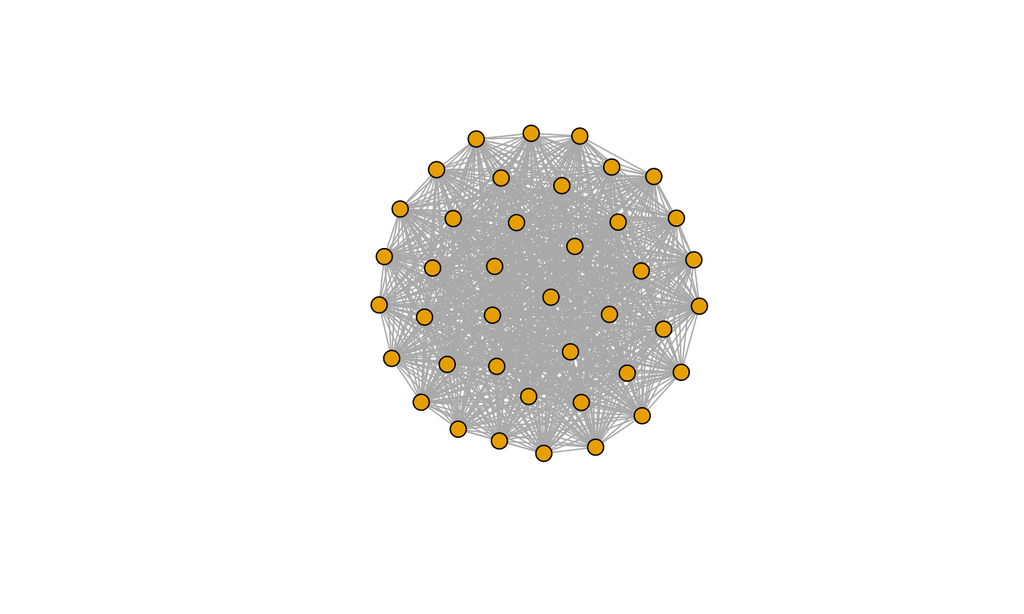

```r
fg <- make_full_graph(40)

plot(fg, vertex.size=10, vertex.label=NA)
```

## Specific Graphs

Graphs with a “notable” structure

- Tree: in graph theory, a Tree is an undirected graph in which any two vertices are connected by exactly one path, or equivalently a connected acyclic undirected graph.

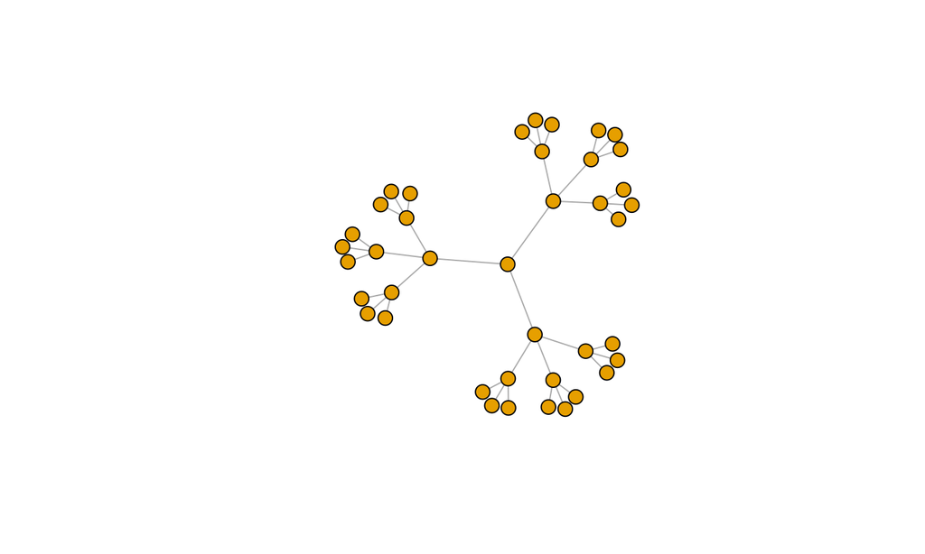

```r
tr <- make_tree(40, children = 3, mode = "undirected")

plot(tr, vertex.size=10, vertex.label=NA)
```

## Specific Graphs

Graphs with a “notable” structure

- Star Graph: a form of tree with a nice layout

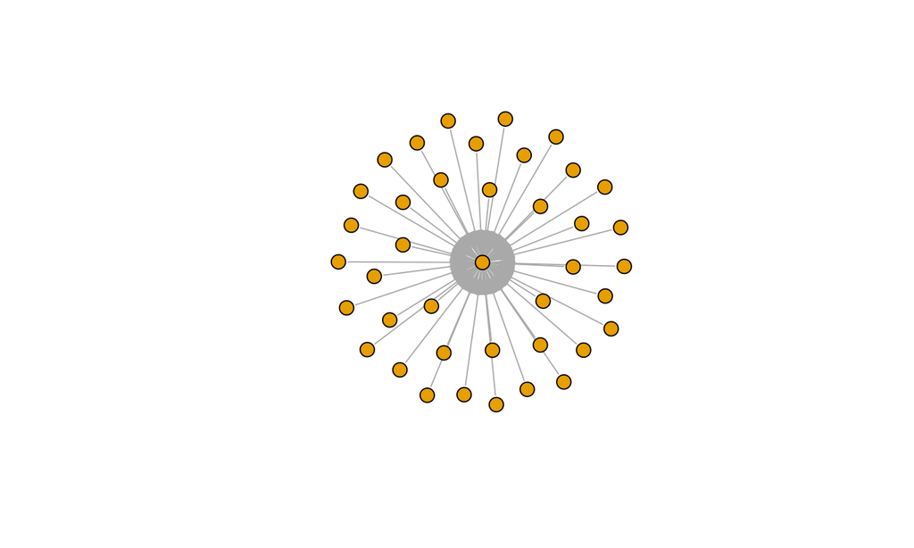

```r
st <- make_star(40)

plot(st, vertex.size=10, vertex.label=NA, directed = F)
```

## Specific Graphs

Graphs with a “notable” structure

- Ring graph

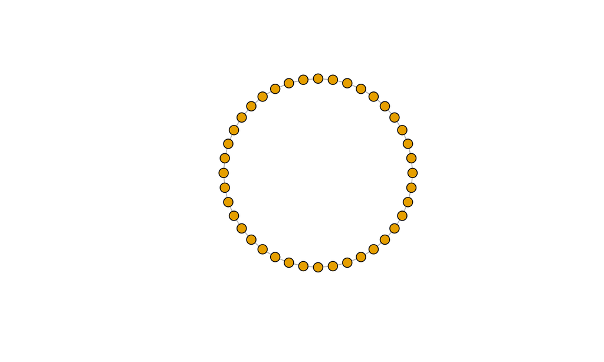

```r
rn <- make_ring(40)
plot(rn, vertex.size=10, vertex.label=NA, layout = layout_in_circle)
```

## Graph Models

- Erdos-Renyi random graph

There are two possible models for creating a random graph that are called **gnp** and **gnm**

- The first model uses as a parameter the probability of connection between two nodes
- The second model uses as a parameter the number of edges

## Graph Models

In the case of **gnp** the number of edges changes over realizations, in the **gnm** it doesn’t

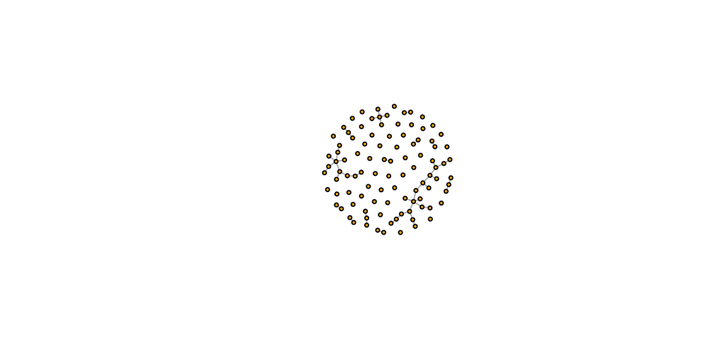

```r
erP <- sample_gnp(n=100, p=0.01, directed = F)
plot(erP, vertex.size=6, vertex.label=NA)## ('n' is number of nodes, 'p' is the number of edges)
```

```r
c(ecount(erP),ecount(sample_gnp(n=100, p=0.01)),ecount(sample_gnp(n=100, p=0.01)))
```

```
## [1] 47 39 52
```

## Graph Models

Let’s do the same thing with **gnm** let’s say that \(p = 0.01\) then \(0.01 = \frac{2m}{n(n-1)}\) thus \(\frac{n(n-1)}{2}*p = m\) and \(m = 49.5\).

\(\frac{n(n-1)}{2}\) is the maximum number of links in a network with \(n\) nodes

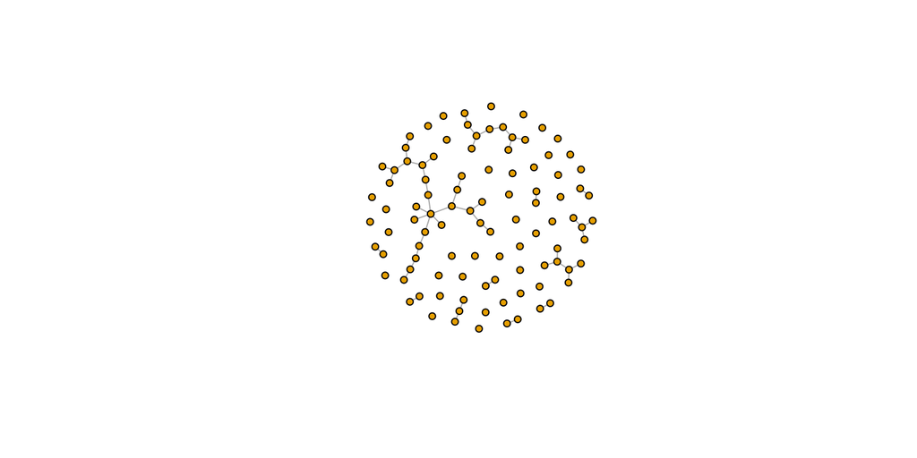

```r
erM <- sample_gnm(n = 100, m = 50, directed = F)
plot(erM, vertex.size=6, vertex.label=NA)
```

## Graph Models

Erdos-Renyi with number of nodes \(n\) and mean degree \(\overline{k}\) as parameters

\(\overline{k} = 2m/n\)

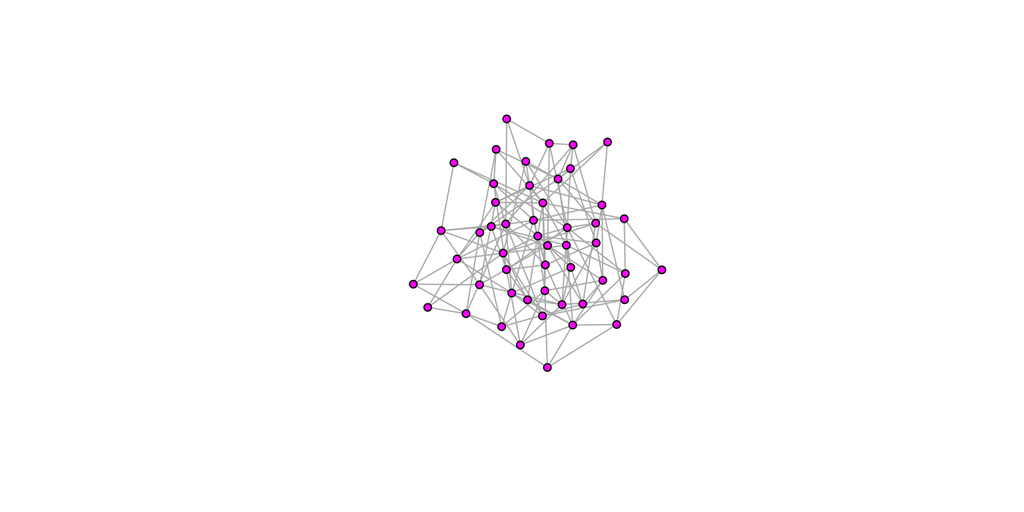

```r
gnm_mean_degree <- function(n,mean_k){
  m = round((n*mean_k)/2)
  g = sample_gnm(n, m) }
g <- gnm_mean_degree(50,6)
plot(g, vertex.size = 6, vertex.label = NA, vertex.color = "magenta")
```

## Graph Models

Evolution of the Largest Connected Component of an Erdos-Renyi random graph

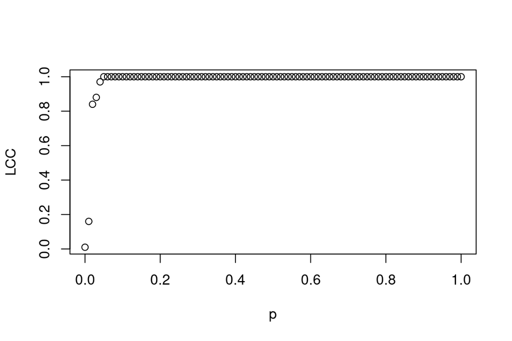

```r
er_lcc <- c()

for(p in seq(from = 0, to =  1, by =0.01)){
  er = sample_gnp(100,p, directed = F, loops = F)
  #plot(ws, layout = layout.circle(ws))
  lcc = max(components(er)$csize)
 # print(cc)
  er_lcc = c(er_lcc, lcc)
  }
plot(x = seq(from = 0, to =  1, by =0.01), y = er_lcc/vcount(er), xlab = "p", ylab = "LCC")
```

## Graph Models

The previous simulations produces a different Erdos-Renyi graph each time. To create a reproducible simulation we should set the seed that generated the random sequence.

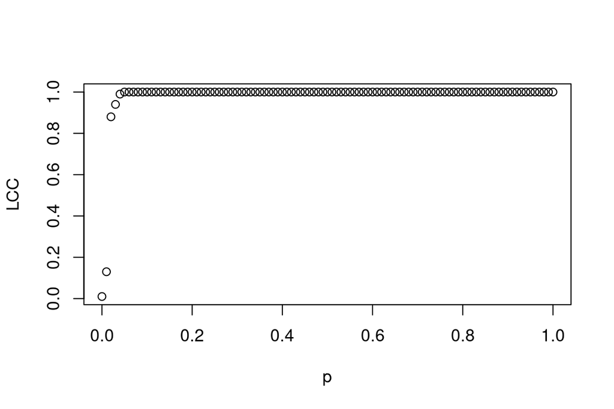

```r
er_lcc <- c()
set.seed(100)
for(p in seq(from = 0, to =  1, by =0.01)){
  er = sample_gnp(100,p, directed = F, loops = F)
  lcc = max(components(er)$csize)
  er_lcc = c(er_lcc, lcc)
  }
plot(x = seq(from = 0, to =  1, by =0.01), y = er_lcc/vcount(er), xlab = "p", ylab = "LCC")
```

## Graph Models

Let’s do a better visualization

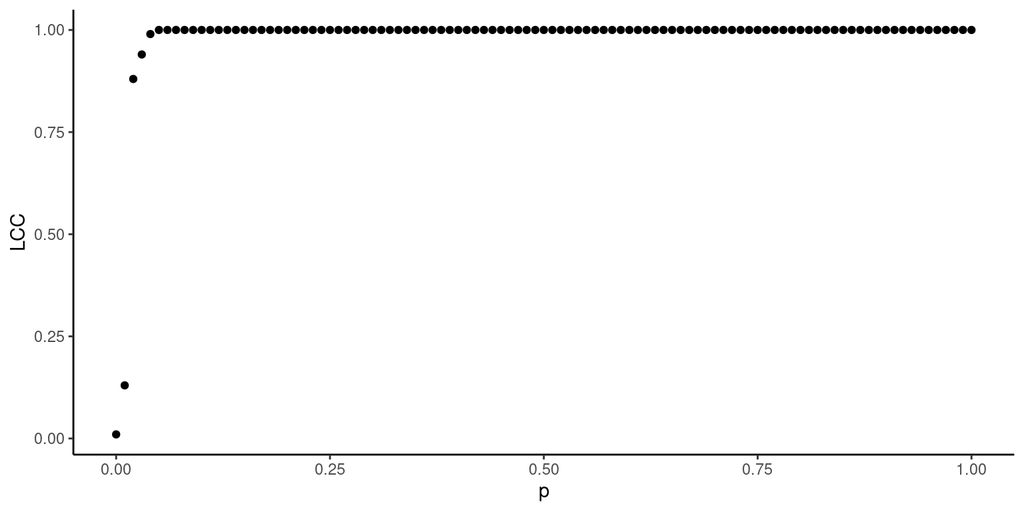

```r
library(dplyr)
library(ggplot2)
tibble(p = seq(from = 0, to =  1, by =0.01), LCC = er_lcc/vcount(er)) %>%
  ggplot(aes(x = p, y = LCC)) + geom_point() + theme_classic()
```

## Graph Models

Let’s zoom in:

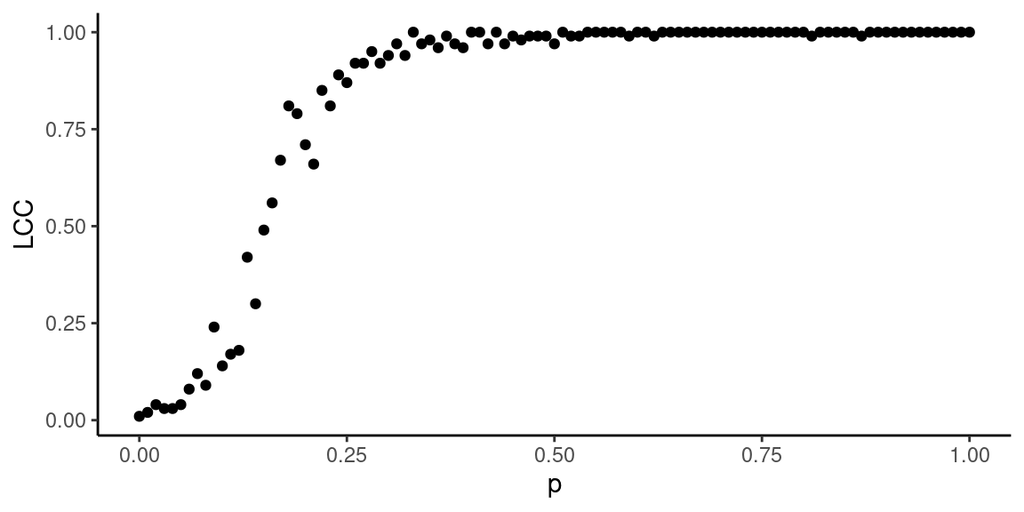

```r
er_lccZoom <- c()
set.seed(100)
for(p in seq(from = 0, to =  0.1, by =0.001)){
  er = sample_gnp(100,p, directed = F, loops = F)
  lcc = max(components(er)$csize)
  er_lccZoom = c(er_lccZoom, lcc)
}
tibble(p = seq(from = 0, to =  1, by =0.01), LCC = er_lccZoom/vcount(er)) %>%
  ggplot(aes(x = p, y = LCC)) + geom_point() + theme_classic()
```

## Graph Models

Now let’s see what happens when we compute both the size of the lcc and the average path length

```r
er_lcc <- c()
er_avpl <- c()
set.seed(100)
for(p in seq(from = 0, to =  1, by =0.01)){
  er = sample_gnp(100,p, directed = F, loops = F)
  lcc = max(components(er)$csize)
  avpl <- average.path.length(er)
  er_lcc = c(er_lcc, lcc)
  er_avpl = c(er_avpl,avpl)
}
#plot(x = seq(from = 0, to =  1, by =0.01), y = er_lcc/vcount(er), xlab = "p", ylab = "LCC")
```

## Graph Models

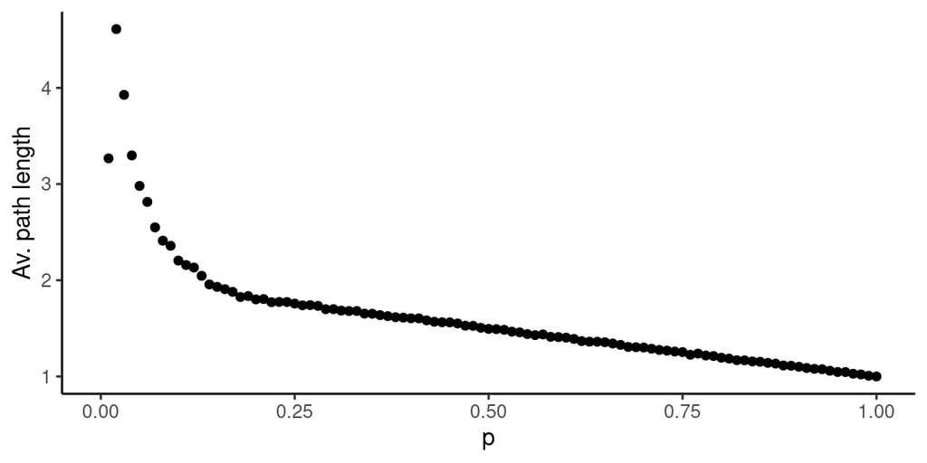

```r
library(dplyr)
library(ggplot2)
tibble(p = seq(from = 0, to =  1, by =0.01), avpl = er_avpl) %>%
  ggplot(aes(x = p, y = avpl)) + geom_point() +
  labs(x = "p",y = "Av. path length") +
  theme_classic()
```

## Graph Models

Watts-Strogatz small-world graph

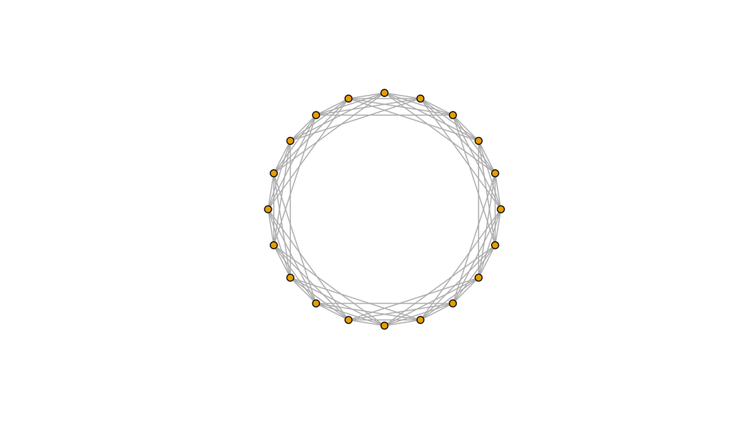

```r
# Creates a lattice with 'dim' dimensions of 'size' nodes each, and rewires edges
# randomly with probability 'p'. You can allow 'loops' and 'multiple' edges.
# The neighborhood in which edges are connected is 'nei'.
sw <- sample_smallworld(dim=1,size=20,nei=4,p=0)#4 links on the left and 4 on the right
plot(sw, vertex.size=6, vertex.label=NA, layout=layout_in_circle)
```

## Graph Models

Watts-Strogatz small-world graph

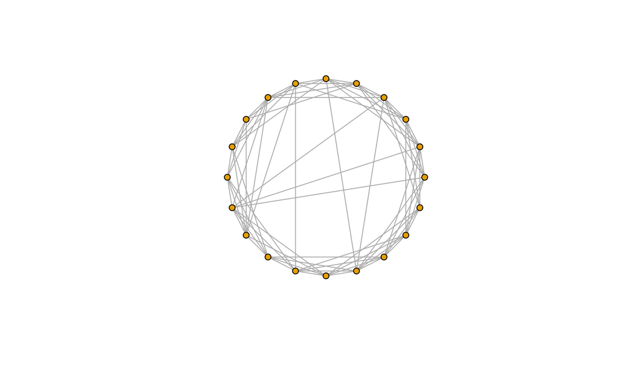

```r
# Creates a lattice with 'dim' dimensions of 'size' nodes each, and rewires edges
# randomly with probability 'p'. You can allow 'loops' and 'multiple' edges.
# The neighborhood in which edges are connected is 'nei'.
sw <- sample_smallworld(dim=1,size=20,nei=4,p=0.05)
plot(sw, vertex.size=6, vertex.label=NA, layout=layout_in_circle, loops = F, multiple = F)
```

## Graph Models

What happens to the degree distribution when we rewire shuffling one of the two endpoints?

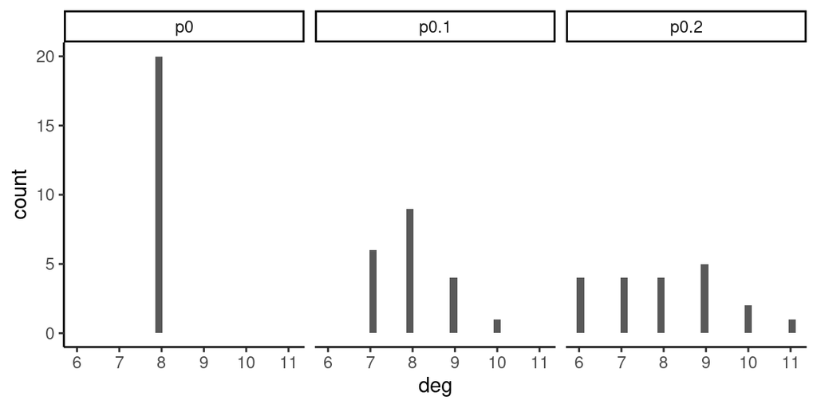

```r
bind_rows(tibble(deg=degree(sample_smallworld(dim=1,size=20,nei=4,p=0)),type = "p0"),
          tibble(deg=degree(sample_smallworld(dim=1,size=20,nei=4,p=0.1)),type = "p0.1"),
          tibble(deg=degree(sample_smallworld(dim=1,size=20,nei=4,p=0.2)),type = "p0.2")) %>%
  ggplot(aes(x=deg)) + geom_histogram() + facet_wrap(vars(type)) + theme_classic()
```

## Graph Models

```r
ws_cc = numeric()
ws_av = numeric()
#fattori di normalizzazione
normcc <- transitivity(sample_smallworld(1, 100, 4, 0, loops = F, multiple = F))
normav <- average.path.length(sample_smallworld(1, 100, 4, 0, loops = F, multiple = F))
#clustering coefficient & av path length VS rewiring probability
for(p in seq(from = 0.0, to =  1, by =0.0001)){#small step size
  ws = sample_smallworld(1, 100, 4, p, loops = F, multiple = F)
  cc = transitivity(ws)
  av = average.path.length(ws)
  ws_cc = c(ws_cc, cc)
  ws_av = c(ws_av, av)
}
```

## Graph Models

The x-axis has a logarithmic scale

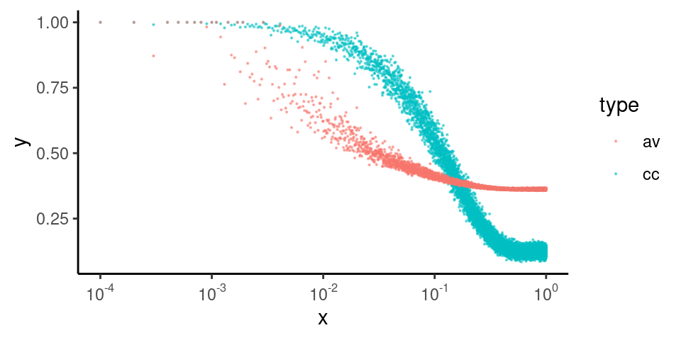

```r
library(dplyr)
library(ggplot2)
p_plot <- seq(from = 0.0, to =  1, by =0.0001)
tibble(x = c(p_plot,p_plot),y = c(ws_cc/normcc,ws_av/normav),
       type = c(rep("cc",length(p_plot)),rep("av",length(p_plot)))) %>%
  ggplot(aes(x = x, y = y, color = type)) + geom_point(size = 0.1, alpha = 0.5) +
  scale_x_log10(breaks = scales::trans_breaks("log10", function(x) 10^x),
   labels = scales::trans_format("log10", scales::math_format(10^.x))) +
  theme_classic()
```

## Graph Models

Let’s see what happens when we remove the log scale

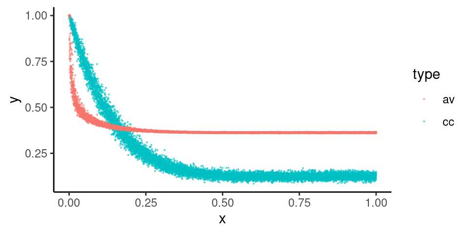

[output not shown]

```r
library(dplyr)
library(ggplot2)
tibble(x = c(p_plot,p_plot),y = c(ws_cc/normcc,ws_av/normav),
       type = c(rep("cc",length(p_plot)),rep("av",length(p_plot)))) %>%
  ggplot(aes(x = x, y = y, color = type)) + geom_point(size = 0.1, alpha = 0.5) +
  theme_classic()
```